# 131 project

Paul Zhang

2024-09-02

```r
library(ggplot2)
library(tidyverse)
library(tidymodels)
library(ThemePark)
library(remotes)
library(dplyr)

library(naniar)
library(corrplot)
library(discrim)
library(kknn)
library(yardstick)
library(kableExtra)
tidymodels_prefer()

set.seed(555)
```

## Intrduction

This project is meant to analyze the crimes happened in the city Minneapolis, Minnesota using machine learning models, and eventually we will predict crime types with variables that are relevant. In this project, we will be using supervised models to perform classification prediction on our response variable.

The data set is from kaggle.com, it records crimes committed in Minneapolis from 2010 and 2016. The data set contains over 130,000 observations and 35 types of crimes, and also relevant variables like the begin time of the crime, the neighborhood and the crime descriptions. And here is the link to the online data set: [crimes data](https://www.kaggle.com/datasets/mrisdal/minneapolis-incidents-crime?select=crimes.csv).

The motive of doing the analysis is to see if there are models with relevant predictors to predict where and when will what kind of crime be committed, which will help people live around to protect themselves better and provide insightful information for local police offices to allocate the right amount of police forces at right place and right time.

## Exploratory Data Analysis

First we load our raw data, and to see what is the size of our data set.

```r
# Read in data set.
library(readr)
crimes <- read_csv("C:/Users/Zhengri.DESKTOP-UCNCNBE/Desktop/PSTAT 131/project/crimes.csv")
crimes %>% head()
```

```
## # A tibble: 6 × 20
##   publicaddress           controlnbr CCN            Precinct ReportedDate
##   <chr>                        <dbl> <chr>             <dbl> <dttm>
## 1 0029XX Chicago AV S           2001 MP 2010 049740        3 2010-02-22 13:40:00
## 2 0049XX Queen AV N             2002 MP 2010 999144        4 2010-02-22 13:38:15
## 3 0003XX 16 AV SE               2003 MP 2010 999143        2 2010-02-22 13:40:50
## 4 0016XX University AV SE       2004 MP 2010 049741        2 2010-02-22 14:15:00
## 5 00003X 9 ST S                 2005 MP 2010 049818        1 2010-02-22 15:00:00
## 6 0003XX Washington AV SE       2006 MP 2010 049715        2 2010-02-22 15:17:00
## # ℹ 15 more variables: BeginDate <dttm>, Time <time>, Offense <chr>,
## #   Description <chr>, UCRCode <dbl>, EnteredDate <dttm>, Long <dbl>,
## #   Lat <dbl>, x <dbl>, y <dbl>, Neighborhood <chr>, lastchanged <dttm>,
## #   LastUpdateDate <dttm>, OBJECTID <dbl>, ESRI_OID <dbl>
```

```r
dim(crimes)
```

```
## [1] 136121     20
```

Here we can see that there are 136121 observations and 20 variables. Since the data set is quite large, we are going to analyze the crimes committed from the year 2015 to 2016. Here we filtered the observations according to the `BeginDate`.

```r
# Filter data from 2015 to 2016
crimes_filtered <- crimes %>%
  filter(crimes$BeginDate > "2015-01-01 00:00:00")
crimes_filtered
```

```
## # A tibble: 28,550 × 20
##    publicaddress           controlnbr CCN           Precinct ReportedDate
##    <chr>                        <dbl> <chr>            <dbl> <dttm>
##  1 11 ST N / Currie AV           1001 MP 2015 0233…        1 2015-01-21 13:56:00
##  2 0007XX 21 AV N                1002 MP 2015 9996…        4 2015-01-21 14:24:15
##  3 00005X 10 ST S                1004 MP 2015 9996…        1 2015-01-21 15:06:34
##  4 26 AV N / Broadway AV W       1005 MP 2015 0233…        4 2015-01-21 15:11:00
##  5 0042XX 28 AV S                1006 MP 2015 0232…        3 2015-01-21 15:18:00
##  6 0015XX Penn AV N              1007 MP 2015 0234…        4 2015-01-21 15:45:00
##  7 0018XX Irving AV N            1008 MP 2015 0234…        4 2015-01-21 16:02:00
##  8 0020XX Golden Valley RD       1009 MP 2015 0234…        4 2015-01-21 16:15:00
##  9 0004XX 31 AV N                1010 MP 2015 0233…        4 2015-01-21 16:21:00
## 10 0007XX Nicollet Mall          1011 MP 2015 0234…        1 2015-01-21 16:39:00
## # ℹ 28,540 more rows
## # ℹ 15 more variables: BeginDate <dttm>, Time <time>, Offense <chr>,
## #   Description <chr>, UCRCode <dbl>, EnteredDate <dttm>, Long <dbl>,
## #   Lat <dbl>, x <dbl>, y <dbl>, Neighborhood <chr>, lastchanged <dttm>,
## #   LastUpdateDate <dttm>, OBJECTID <dbl>, ESRI_OID <dbl>
```

When we look at the missing data, we can see that the most missing data is from `OBJECTID` and `ESRI_OID`. Since they are also irrelevant, we are going to exclude them from our data set. Then here we have total 18 variables.

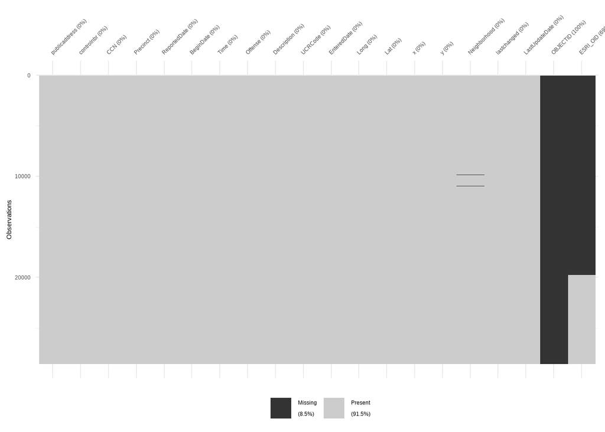

```r
# Missing data analysis.
vis_miss(crimes_filtered)
```

```r
# Deselect the columns that with most missing data
crimes_filtered <- crimes_filtered %>% select(-OBJECTID, -ESRI_OID)
crimes_filtered %>% head()
```

```
## # A tibble: 6 × 18
##   publicaddress           controlnbr CCN            Precinct ReportedDate
##   <chr>                        <dbl> <chr>             <dbl> <dttm>
## 1 11 ST N / Currie AV           1001 MP 2015 023329        1 2015-01-21 13:56:00
## 2 0007XX 21 AV N                1002 MP 2015 999614        4 2015-01-21 14:24:15
## 3 00005X 10 ST S                1004 MP 2015 999613        1 2015-01-21 15:06:34
## 4 26 AV N / Broadway AV W       1005 MP 2015 023312        4 2015-01-21 15:11:00
## 5 0042XX 28 AV S                1006 MP 2015 023257        3 2015-01-21 15:18:00
## 6 0015XX Penn AV N              1007 MP 2015 023437        4 2015-01-21 15:45:00
## # ℹ 13 more variables: BeginDate <dttm>, Time <time>, Offense <chr>,
## #   Description <chr>, UCRCode <dbl>, EnteredDate <dttm>, Long <dbl>,
## #   Lat <dbl>, x <dbl>, y <dbl>, Neighborhood <chr>, lastchanged <dttm>,
## #   LastUpdateDate <dttm>
```

After that, we are going to select which are the variables we need for the model. Firstly let’s look at `Offense` and `UCRCode`, which would be our main focus of this data set. Here we are going to show the distribution of these two variables and the relationship between them.

```r
# Make "Offense" and "UCRCode" factors
crimes_filtered$Offense <- factor(crimes_filtered$Offense)
crimes_filtered$UCRCode <- factor(crimes_filtered$UCRCode)
```

The following is the distribution of types of crimes (`Offense`).

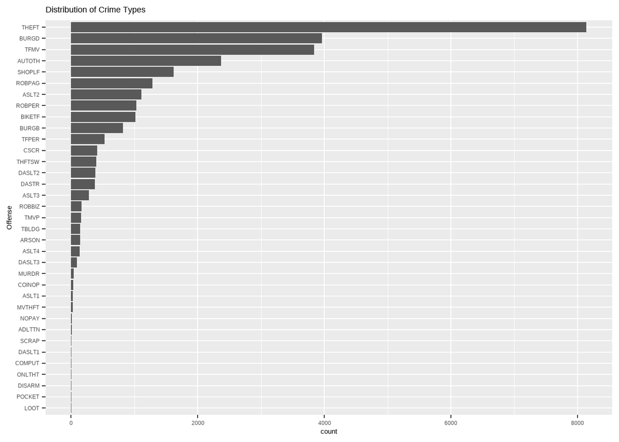

```r
# Plot distribution of "Offense".
ggplot(data = crimes_filtered, aes(y = reorder(Offense, Offense, length))) +
  geom_bar() +
  labs(title = "Distribution of Crime Types", x = "count", y = "Offense")
```

Also, here is a proportional stacked bar graph to provide a overview of crime type in terms of UCR code. We used variable `Description` to fill the bars since they are the same as `Offense`, only to provide detailed explanation.

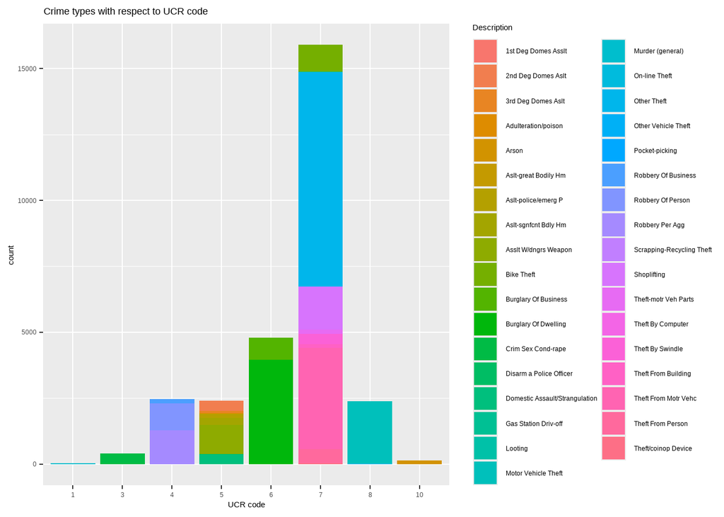

```r
# Plot proportional bar chart
ggplot(crimes_filtered, aes(fill = Description, x = UCRCode)) +
  geom_bar() +
  labs(title = "Crime types with respect to UCR code", x = "UCR code")
```

We can see that there are too many categorical values for `Offense` and some of them only have a small count. So we are going to combine some of the types of crime according to `UCRCode`.

Each UCR code represents a larger range of crimes, which can help us combine minority data for better model performance. Here is an example that when `UCRCode = 5`, we have assault crimes like assault with dangerous weapon and different degrees of domestic assault. We will also be doing the combination with `UCRCode = 4` for robbery, `UCRCode = 6` for burglary and `UCRCode = 8` for vehicle theft.

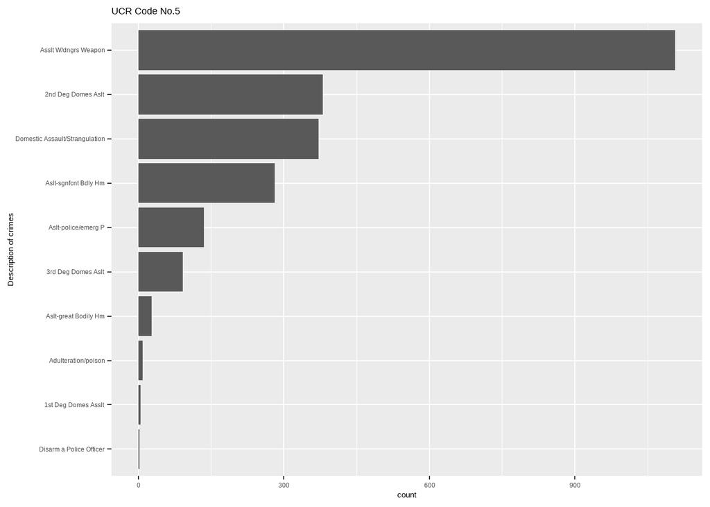

```r
# Distribution of crimes with UCR code = 5
crimes_asslt <- crimes_filtered %>% filter(crimes_filtered$UCRCode == 5)
ggplot(data = crimes_asslt, aes(y = reorder(Description, Description, length))) +
  geom_histogram(stat = "count") +
  labs(title = "UCR Code No.5", y = "Description of crimes")
```

As for crime types covered by `UCRCode = 7`, `Other Theft` (`THEFT` in variable `Offense`) takes up a large proportion, so we are going to consider it separately, and make the other types of theft, including shoplifting and theft by swindle, into another type.

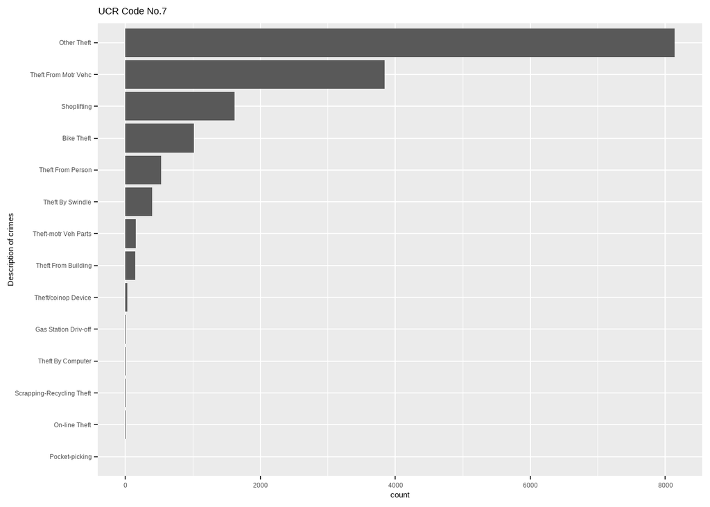

```r
# Distribution of crimes with UCR code = 7
crimes_theft <- crimes_filtered %>% filter(crimes_filtered$UCRCode == 7)
ggplot(data = crimes_theft, aes(y = reorder(Description, Description, length))) +
  geom_histogram(stat = "count") +
  labs(title = "UCR Code No.7", y = "Description of crimes")
```

Therefore, we are forming a new variable with categorical values `murder`, `sex_crim`, `rob`, `asslt`, `burgl`, `thft_gnrl`, `thft_othr`, `thft_vehic` and `arson`, which are 9 types in total. Also, we are going to choose `Time`, `x`, `y` and `offense_new` for fitting the model.

```r
# Create new column with re-categorized crimes
crimes_filtered <- crimes_filtered %>%
  mutate(offense_new = recode(Offense,
    "TFMV" = "thft_gnrl", "SHOPLF" = "thft_gnrl", "BIKETF" = "thft_gnrl", "TFPER" = "thft_gnrl",
    "THFTSW" = "thft_gnrl", "TMVP" = "thft_gnrl", "TBLDG" = "thft_gnrl", "COINOP" = "thft_gnrl",
    "NOPAY" = "thft_gnrl", "SCRAP" = "thft_gnrl", "COMPUT" = "thft_gnrl", "ONLTHT" = "thft_gnrl",
    "POCKET" = "thft_gnrl", "THEFT" = "thft_othr",
    "MVTHFT" = "thft_vehic", "AUTOTH" = "thft_vehic",
    "ARSON" = "arson", "MURDR" = "murder", "CSCR" = "sex_crim",
    "ROBPER" = "rob", "ROBPAG" = "rob", "ROBBIZ" = "rob",
    "ASLT1" = "asslt", "ASLT2" = "asslt", "ASLT3" = "asslt",
    "ASLT4" = "asslt", "DASLT1" = "asslt", "DASLT2" = "asslt", "DASLT3" = "asslt",
    "DASTR" = "asslt", "ADLTTN" = "asslt", "DISARM" = "asslt",
    "LOOT" = "burgl", "BURGD" = "burgl", "BURGB" = "burgl"))

# Reserve only useful variables.
crimes_selected <- crimes_filtered %>% select(Time, x, y, offense_new)
crimes_selected %>% head()
```

```
## # A tibble: 6 × 4
##   Time         x       y offense_new
##   <time>   <dbl>   <dbl> <fct>
## 1 13:22  526685. 168135. asslt
## 2 00:00  524382. 176314. thft_othr
## 3 11:00  527772. 166959. thft_othr
## 4 12:15  518561. 178369. thft_gnrl
## 5 15:30  539265. 149407. thft_othr
## 6 14:00  519532. 174142. burgl
```

Finally, we are going to extract the hour value from `Time`.

```r
# add `hour` column
crimes_final <- crimes_selected %>% mutate(hour = hour(Time))
crimes_final
```

```
## # A tibble: 28,550 × 5
##    Time         x       y offense_new  hour
##    <time>   <dbl>   <dbl> <fct>       <int>
##  1 13:22  526685. 168135. asslt          13
##  2 00:00  524382. 176314. thft_othr       0
##  3 11:00  527772. 166959. thft_othr      11
##  4 12:15  518561. 178369. thft_gnrl      12
##  5 15:30  539265. 149407. thft_othr      15
##  6 14:00  519532. 174142. burgl          14
##  7 14:00  521799. 175608. burgl          14
##  8 15:30  519857. 175624. thft_othr      15
##  9 13:57  525409. 180635. burgl          13
## 10 15:00  528572. 167679. thft_othr      15
## # ℹ 28,540 more rows
```

And the variable we will be using are: - `x`: x coordinate where the crime happened, numerical. - `y`: y coordinate where the crime happened, numerical. - `hour`: the hour that the crime begin in a day, in 24-hour format. - `offense_new`: crime types, response variable.

## Set up model

Here we will be starting to build our model.

### Trian & test split And K-fold cross validation

For our data set, we are going to split it into training and testing sets with 80% and 20%. Also, we will be doing a 5-fold cross validation.

```r
# splitting into training and testing
crimes_split <- crimes_final %>% initial_split(prop = 0.8, strata = "offense_new")
crimes_train <- training(crimes_split)
crimes_test <- testing(crimes_split)
dim(crimes_train)
```

```
## [1] 22838     5
```

```r
dim(crimes_test)
```

```
## [1] 5712    5
```

```r
# validation set
crimes_valid <- validation_split(crimes_train, prop = 0.75, strata = "offense_new")
crimes_folds <- vfold_cv(crimes_train, v = 5)
```

Here we can see that the training set has 22838 observations and testing set has 5712 observations. And the following plot is the visualization of relationship between our predictors response of the data set, where the sample size is reduced to 10% of our training set.

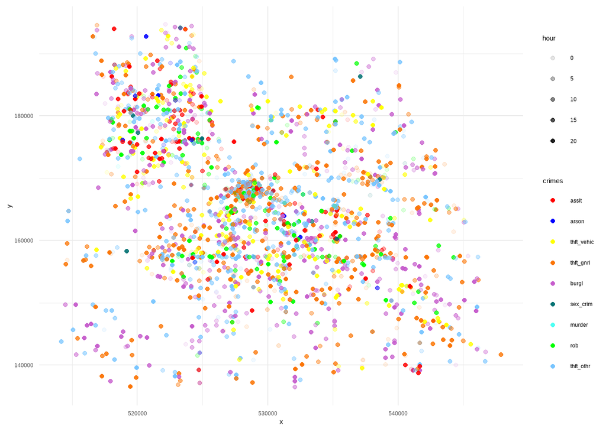

```r
ggplot(crimes_train %>% sample_frac(0.1),
       aes(x = x, y = y, color = offense_new)) +
  geom_point(aes(alpha = hour)) +
  scale_color_manual(values = c("red","blue","yellow",
                                "#fb7504","#c65ccc","#047374",
                                "#4dfff3","green","#78c5ff")) +
  theme_minimal() +
  xlab("x") +
  ylab("y") +
  labs(color = "crimes", alpha = "hour")
```

From the plot we can see roughly where were the crimes located in the city and when did they take place. There is pattern that how they distributed for some crime types, but we still need to fit in model to see any useful result.

### Recipe building

Before fitting our data to various models, we are going to build a recipe. Since the rearranged data still having strongly imbalanced observations across values, we are going to upsampling the minority class to 30% of the majority and downsampling the majority to its 80%.

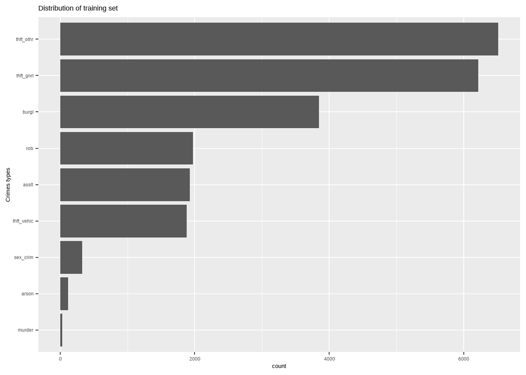

```r
ggplot(data = crimes_train, aes(y = reorder(offense_new, offense_new, length))) +
  geom_histogram(stat = "count") +
  labs(title = "Distribution of training set", y = "Crimes types")
```

```r
library(themis)

crimes_recipe <- recipe(offense_new ~ hour + x + y, data = crimes_train) %>%
  step_normalize(all_numeric_predictors()) %>%
  step_upsample(offense_new, over_ratio = 0.3, skip = FALSE) %>%
  step_downsample(offense_new, under_ratio = 0.8, skip = FALSE)

prep(crimes_recipe) %>%
  bake(new_data = crimes_train) %>%
  head() %>%
  kable() %>%
  kable_styling(full_width = F) %>%
  scroll_box(width = "100%", height = "200px")
```

| hour | x | y | offense_new |
| --- | --- | --- | --- |
| -1.4789135 | -1.5901137 | 1.2175350 | asslt |
| 1.2575453 | -0.5676559 | 0.9034077 | asslt |
| -1.2052677 | 0.0738908 | -0.0138426 | asslt |
| -1.6157365 | -1.3742883 | 1.0659350 | asslt |
| 1.3943682 | -0.1186275 | -1.9379849 | asslt |
| 0.8470765 | -1.3387015 | 0.8224622 | asslt |

## Model building

The models we will be using are K-nearest neighbor, quadratic discriminant analysis, random forest and gradient-boosted trees, where they will make classification predictions if they are fitting well. The process is are: - Setting up models with classification mode and suitable engines; - build up the workflow with models we just created and the recipe; and for K-nearest neighbor, random forest and gradient-boosted trees model, we - set up tuning grid with hyperparameters that we want to tune; - tune the model and choose the best performing model form the tuning grid; then for all four models, we - fit the model to our training set; - save the results to .rda files and load back for analysis. And to make the project file concise, the above process is done in a separate .R file. The metric will be using is the area under ROC curve (roc_auc).

```r
load("C:/Users/Zhengri.DESKTOP-UCNCNBE/Desktop/PSTAT 131/project/knn_tune.rda")
load("C:/Users/Zhengri.DESKTOP-UCNCNBE/Desktop/PSTAT 131/project/rf_tune.rda")
load("C:/Users/Zhengri.DESKTOP-UCNCNBE/Desktop/PSTAT 131/project/bt_tune.rda")
load("C:/Users/Zhengri.DESKTOP-UCNCNBE/Desktop/PSTAT 131/project/quad_dis_fit.rda")
load("C:/Users/Zhengri.DESKTOP-UCNCNBE/Desktop/PSTAT 131/project/bt_final.rda")
```

### Hyperparameter tuning

For tuning hyperparameters, we will be using the function `autoplot()` to visualize the tuning grid and see which model perform better with the best hyperparameter value.

#### K-nearest neighbor model

Here we tuned the number of nearest neighbors (`neighbors`), where we set the range from 10 to 20 with 10 levels. After loading from the .rda file and do `autoplot()`, we can see that the roc_auc value with respect to the number of nearest neighbors.

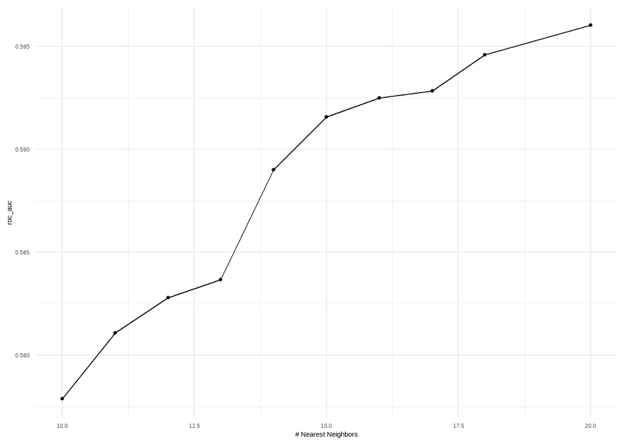

```r
autoplot(knn_tune, metric = "roc_auc") + theme_minimal()
```

```r
knn_roc <- show_best(knn_tune, n = 1, metric = "roc_auc") %>%
  select(mean)
best_knn <- select_best(knn_tune, metric = "roc_auc")
best_knn
```

```
## # A tibble: 1 × 2
##   neighbors .config
##       <int> <chr>
## 1        20 Preprocessor1_Model10
```

Combined with `show_best()` function, we get the best number of nearest neighbors is 20. However, the KNN model do not perform well overall with the mean roc_auc value only to increase a little along with increasing of number of nearest neighbors, while the highest value from out tuning grid is only 0.596.

#### Random forest

Here we tuned the number of predictors at each splitting (`mtry`), range from 1 to 3, number of trees (`trees`), range from 200 to 400, and minimum number of data points in a node before splitting (`min_n`), range from 10 to 20, where the levels are all 5.

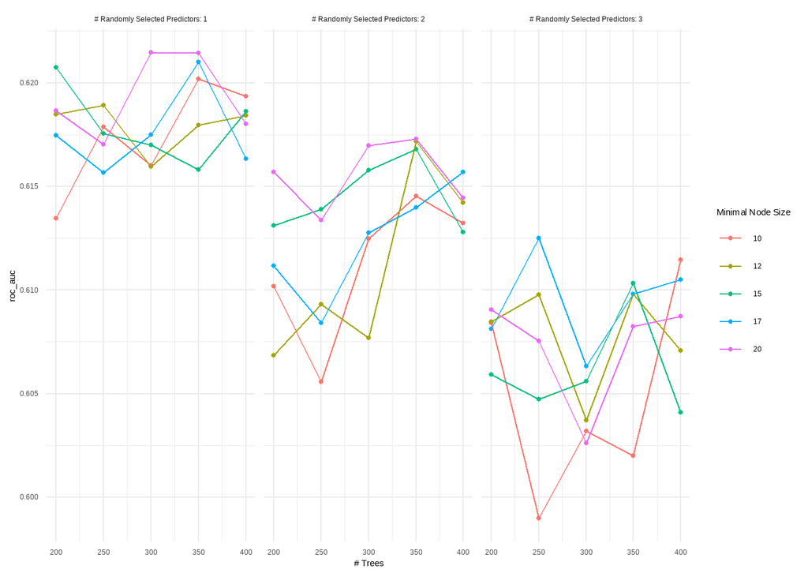

```r
autoplot(rf_tune, metric = "roc_auc") + theme_minimal()
```

```r
rf_roc <- show_best(rf_tune, n = 1, metric = "roc_auc") %>%
  select(mean)
best_rf <- select_best(rf_tune, metric = "roc_auc")
best_rf
```

```
## # A tibble: 1 × 4
##    mtry trees min_n .config
##   <int> <int> <int> <chr>
## 1     1   300    20 Preprocessor1_Model67
```

From above plot, we have a best model with 1 random selected predictors, 300 trees and 20 data points in a node, and the mean roc_auc value has come to 0.62, which shows a better performance.

#### Gradient-boosted trees

Similar from the random forest, we tuned `mtry` and `trees` with same range, and we added learning rate (`learn_rate`) here, range from -10 to -1.

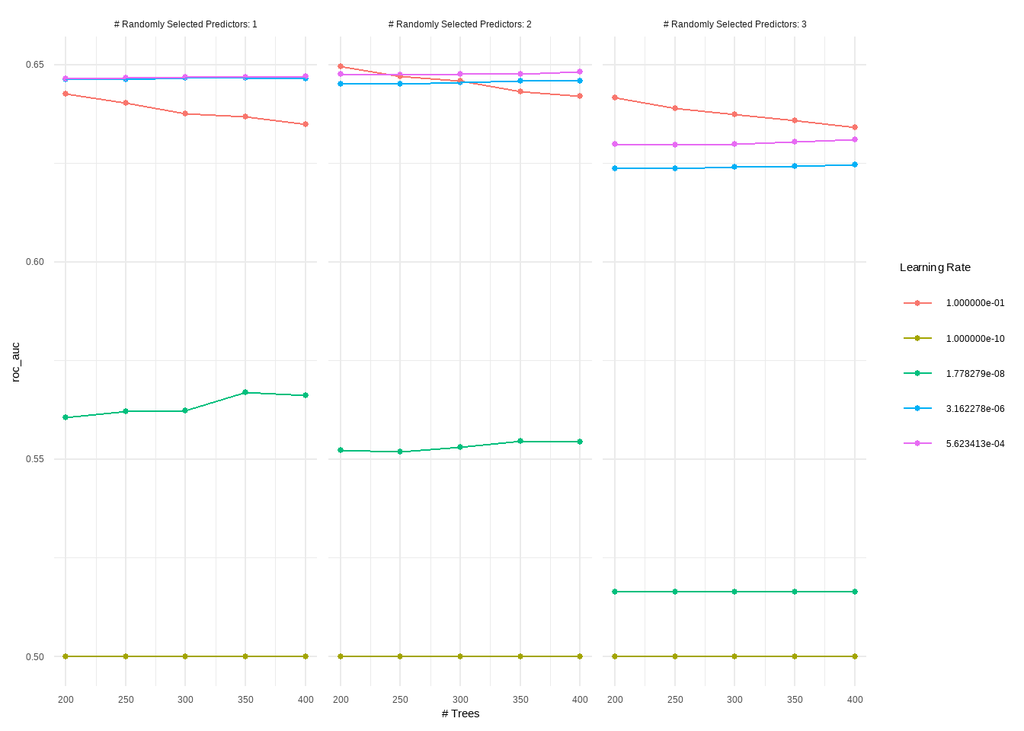

```r
autoplot(bt_tune, metric = "roc_auc") + theme_minimal()
```

```r
bt_roc <- show_best(bt_tune, n = 1, metric = "roc_auc") %>%
  select(mean)
best_bt <- select_best(bt_tune, metric = "roc_auc")
best_bt
```

```
## # A tibble: 1 × 4
##    mtry trees learn_rate .config
##   <int> <int>      <dbl> <chr>
## 1     2   200        0.1 Preprocessor1_Model46
```

From above plot, we have a best model with 2 random selected predictors, 200 trees and 0.1 learning rate, and the mean roc_auc value is the best among the three models we have tuned, which is 0.65.

### Find the best model

To choose the best performing model, we need to see how does our QDA model working by fitting to training set.

```r
quad_dis_predict <- predict(quad_dis_fit, new_data = crimes_train)
quad_dis_predict <- bind_cols(quad_dis_predict, crimes_train) %>%
  rename(predicted = .pred_class)
quad_roc <- augment(quad_dis_fit, new_data = quad_dis_predict) %>%
  roc_auc(truth = offense_new,
          .pred_arson, .pred_murder, .pred_sex_crim, .pred_rob,
          .pred_asslt, .pred_burgl, .pred_thft_gnrl, .pred_thft_othr,
          .pred_thft_vehic) %>%
  select(.estimate)
```

```r
roc_value <- c(bt_roc$mean, rf_roc$mean, knn_roc$mean,
               quad_roc$.estimate)
model_name <- c("Gradient-boosted trees", "Random forest",
                "K_nearest neighbors", "Quadratic discriminant analysis")
model_results <- tibble(Model = model_name, ROC_AUC = roc_value)
model_results
```

```
## # A tibble: 4 × 2
##   Model                           ROC_AUC
##   <chr>                             <dbl>
## 1 Gradient-boosted trees            0.650
## 2 Random forest                     0.621
## 3 K_nearest neighbors               0.596
## 4 Quadratic discriminant analysis   0.457
```

In this case, we will be fitting our Gradient-boosted trees model to the testing set to evaluate performance.

### Gradient-boosted trees performance

We first finalize the workflow and fit it to our training set, and then create a variable importance plot using `vip()` to show the how important the predictors are in prediction.

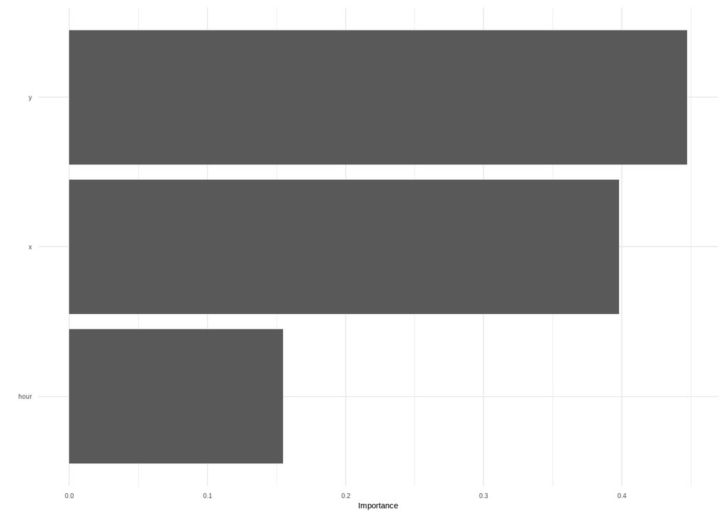

```r
# ploting vip
library(vip)
final_fit %>% extract_fit_parsnip() %>%
  vip() +
  theme_minimal()
```

```r
# fit to testing set
final_bt_model_test <- augment(final_fit,
                               crimes_test) %>%
  select(offense_new, starts_with(".pred"))
# performance on testing set
roc_auc(final_bt_model_test, truth = offense_new,
          .pred_arson, .pred_murder, .pred_sex_crim, .pred_rob,
          .pred_asslt, .pred_burgl, .pred_thft_gnrl, .pred_thft_othr,
          .pred_thft_vehic)
```

```
## # A tibble: 1 × 3
##   .metric .estimator .estimate
##   <chr>   <chr>          <dbl>
## 1 roc_auc hand_till      0.431
```

From the variable importance plot, we see that the y and then x coordinates are more important. However, the model is generally not useful in predicting any of the crime types, where the roc_auc value 0.43, and the prediction result is visualized by ROC curves below for predicting each value from `offense_new` in our testing set.

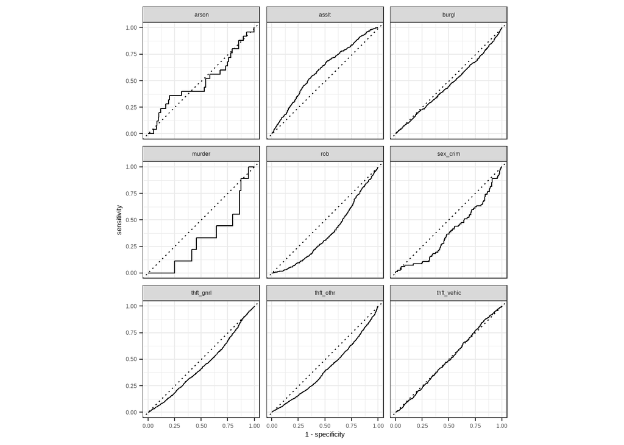

```r
roc_curve(final_bt_model_test, truth = offense_new,
          .pred_arson, .pred_murder, .pred_sex_crim, .pred_rob,
          .pred_asslt, .pred_burgl, .pred_thft_gnrl, .pred_thft_othr,
          .pred_thft_vehic) %>% autoplot()
```

## Conclusion

From the exploration of the raw data, to setting up the model using various resampling methods; by trying on fitting some model, we find that the models would perform no better than random guessing. Besides the trimmed sample size and strongly imbalanced categorical variables, the choice of predictors and model selection are still worth more research on.

When looking at the model performance, we can see that the simpler models like QDA and KNN has performance not as good as random forest and gradient-boosted trees in terms of predicting response that has large amount of categorical values. In that case, we may expect considering more predictors or more focused predictions like whether someone will commit certain crime at certain time and location.

Overall, we have investigated and learned a lot from the whole process, and predicting classification models indeed need more adjusting and tuning to deal with complicated problems like crimes. In conclusion, data analysis and machine learning techniques are powerful and we have more to learn to effectively utilized them.